# BIOS 544: Alcohol Use and Virologic Failure in HIV Patients

Group 8: Yuchen Gong

Published

April 27, 2026

## Research Question

What is the impact of alcohol use on virologic failure in HIV patients? We hypothesize that high alcohol use is associated with increased odds of virologic failure compared to no alcohol use.

## 1. Setup

```r
# Run this in Console if any package is missing:
# install.packages(c("tidyverse", "broom", "pROC", "ResourceSelection", "caret", "knitr", "kableExtra"))

library(tidyverse)
library(broom)
library(pROC)
library(ResourceSelection)
library(caret)
library(knitr)
library(kableExtra)
```

## 2. Load Data

```r
hiv_data <- read_csv("/Users/yuchen/Documents/emory/bios544/hiv_dataset_11.csv") |>
  rename(
    virologic_failure = VirologicFailure,
    alcohol_use       = AlcoholUse
  ) |>
  mutate(
    virologic_failure = as.integer(virologic_failure),
    alcohol_use       = factor(alcohol_use, levels = c("None", "Moderate", "High"))
  ) |>
  filter(!is.na(virologic_failure), !is.na(alcohol_use))

glimpse(hiv_data)
```

```
Rows: 300
Columns: 11
$ Age               <dbl> 43, 34, 45, 35, 31, 30, 51, 25, 36, 42, 63, 46, 50, …
$ Sex               <chr> "Female", "Female", "Male", "Female", "Male", "Femal…
$ Education         <chr> "Tertiary", "Secondary", "Secondary", "Tertiary", "S…
$ Employment        <chr> "Informal", "Unemployed", "Informal", "Employed", "E…
$ Adherence         <dbl> 0.8478042, 0.8889830, 0.9900386, 0.7837692, 0.477085…
$ CD4               <dbl> 570, 650, 548, 673, 523, 490, 657, 429, 573, 265, 36…
$ ViralLoad         <dbl> 323, 247, 108, 213, 342, 934, 98, 6614, 145, 94, 127…
$ virologic_failure <int> 1, 1, 0, 1, 1, 1, 0, 1, 0, 0, 0, 1, 0, 1, 0, 0, 1, 0…
$ alcohol_use       <fct> None, None, None, Moderate, None, None, High, None, …
$ StigmaScore       <dbl> 1.1693086, 2.1627410, 3.3874171, 4.2253068, 3.882279…
$ DistanceClinicKM  <dbl> 6.4, 0.8, 5.5, 7.0, 12.5, 2.6, 3.9, 7.2, 4.1, 1.1, 1…
```

## 3. Descriptive Statistics

```r
desc_tbl <- hiv_data |>
  group_by(alcohol_use) |>
  summarise(
    N            = n(),
    Failures     = sum(virologic_failure),
    Failure_Rate = paste0(round(mean(virologic_failure) * 100, 1), "%"),
    .groups = "drop"
  )

kable(desc_tbl,
      col.names = c("Alcohol Use", "N", "Virologic Failures (n)", "Failure Rate"),
      caption = "Table 1. Virologic failure by alcohol use category.") |>
  kable_styling(bootstrap_options = c("striped", "hover"), full_width = FALSE) |>
  row_spec(0, bold = TRUE)
```

Table 1. Virologic failure by alcohol use category.

| Alcohol Use | N | Virologic Failures (n) | Failure Rate |
| --- | --- | --- | --- |
| None | 179 | 110 | 61.5% |
| Moderate | 85 | 37 | 43.5% |
| High | 36 | 27 | 75% |

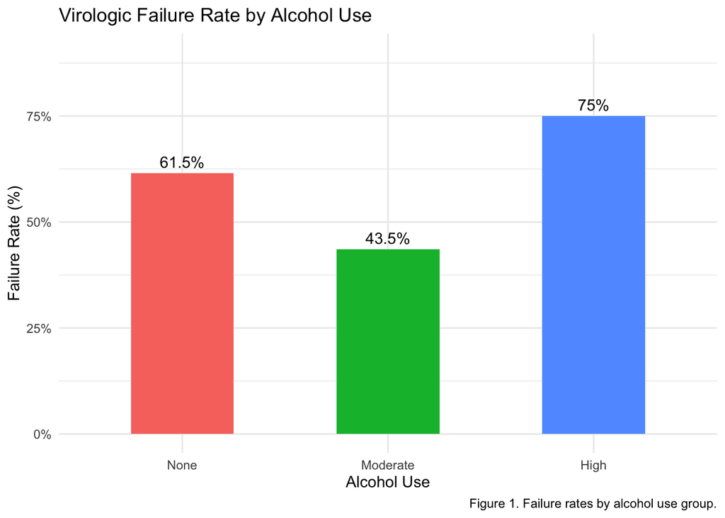

```r
hiv_data |>
  group_by(alcohol_use) |>
  summarise(failure_rate = mean(virologic_failure) * 100, .groups = "drop") |>
  ggplot(aes(x = alcohol_use, y = failure_rate, fill = alcohol_use)) +
  geom_col(width = 0.5, show.legend = FALSE) +
  geom_text(aes(label = paste0(round(failure_rate, 1), "%")), vjust = -0.5) +
  scale_y_continuous(limits = c(0, 90), labels = function(x) paste0(x, "%")) +
  labs(
    title = "Virologic Failure Rate by Alcohol Use",
    x     = "Alcohol Use",
    y     = "Failure Rate (%)",
    caption = "Figure 1. Failure rates by alcohol use group."
  ) +
  theme_minimal()
```

## 4. Logistic Regression Model

```r
model <- glm(
  virologic_failure ~ alcohol_use,
  data   = hiv_data,
  family = binomial(link = "logit")
)

summary(model)
```

```
Call:
glm(formula = virologic_failure ~ alcohol_use, family = binomial(link = "logit"),
    data = hiv_data)

Coefficients:
                    Estimate Std. Error z value Pr(>|z|)
(Intercept)           0.4664     0.1536   3.037  0.00239 **
alcohol_useModerate  -0.7267     0.2673  -2.719  0.00656 **
alcohol_useHigh       0.6322     0.4144   1.526  0.12710
---
Signif. codes:  0 '***' 0.001 '**' 0.01 '*' 0.05 '.' 0.1 ' ' 1

(Dispersion parameter for binomial family taken to be 1)

    Null deviance: 408.18  on 299  degrees of freedom
Residual deviance: 395.57  on 297  degrees of freedom
AIC: 401.57

Number of Fisher Scoring iterations: 4
```

### Odds Ratios & 95% Confidence Intervals

```r
or_tbl <- tidy(model, exponentiate = TRUE, conf.int = TRUE) |>
  mutate(
    term = recode(term,
      "(Intercept)"         = "Intercept (None – ref)",
      "alcohol_useModerate" = "Moderate vs None",
      "alcohol_useHigh"     = "High vs None"
    ),
    across(where(is.numeric), ~ round(.x, 3))
  ) |>
  rename(
    Parameter      = term,
    `Odds Ratio`   = estimate,
    `Std. Error`   = std.error,
    `z value`      = statistic,
    `p-value`      = p.value,
    `95% CI Lower` = conf.low,
    `95% CI Upper` = conf.high
  )

kable(or_tbl,
      caption = "Table 2. Odds ratios with 95% confidence intervals.") |>
  kable_styling(bootstrap_options = c("striped", "hover"), full_width = FALSE) |>
  row_spec(0, bold = TRUE)
```

Table 2. Odds ratios with 95% confidence intervals.

| Parameter | Odds Ratio | Std. Error | z value | p-value | 95% CI Lower | 95% CI Upper |
| --- | --- | --- | --- | --- | --- | --- |
| Intercept (None – ref) | 1.594 | 0.154 | 3.037 | 0.002 | 1.183 | 2.163 |
| Moderate vs None | 0.484 | 0.267 | -2.719 | 0.007 | 0.285 | 0.814 |
| High vs None | 1.882 | 0.414 | 1.526 | 0.127 | 0.863 | 4.456 |

## 5. Model Diagnostics

### ROC Curve & AUC

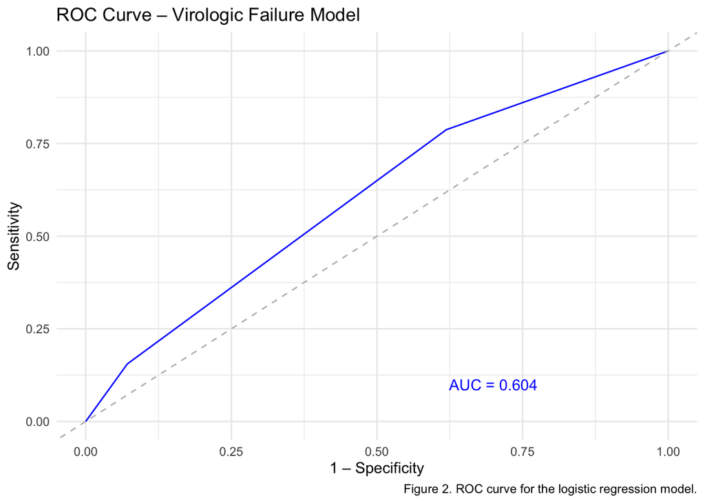

```r
hiv_data$pred_prob <- fitted(model)

roc_obj <- roc(hiv_data$virologic_failure, hiv_data$pred_prob, quiet = TRUE)
auc_val  <- round(auc(roc_obj), 3)

roc_df <- data.frame(
  fpr = 1 - roc_obj$specificities,
  tpr = roc_obj$sensitivities
)

ggplot(roc_df, aes(x = fpr, y = tpr)) +
  geom_line(color = "blue") +
  geom_abline(linetype = "dashed", color = "gray") +
  annotate("text", x = 0.7, y = 0.1,
           label = paste0("AUC = ", auc_val), color = "blue") +
  labs(
    title   = "ROC Curve – Virologic Failure Model",
    x       = "1 – Specificity",
    y       = "Sensitivity",
    caption = "Figure 2. ROC curve for the logistic regression model."
  ) +
  theme_minimal()
```

### Hosmer–Lemeshow Goodness-of-Fit

```r
hl_test <- hoslem.test(hiv_data$virologic_failure, fitted(model), g = 3)
print(hl_test)
```

```
    Hosmer and Lemeshow goodness of fit (GOF) test

data:  hiv_data$virologic_failure, fitted(model)
X-squared = 5.9406e-23, df = 0, p-value < 2.2e-16
```

> **Note:** Because `alcohol_use` has only 3 categories, the Hosmer–Lemeshow test collapses to 0 degrees of freedom and produces an uninterpretable result here. This is a known limitation when the predictor is categorical with few levels. Model fit is better assessed through the AUC (0.604) and the descriptive failure rates in Table 1.

### Confusion Matrix

```r
pred_class <- factor(ifelse(hiv_data$pred_prob >= 0.5, 1, 0))
actual     <- factor(hiv_data$virologic_failure)

confusionMatrix(pred_class, actual, positive = "1")
```

```
Confusion Matrix and Statistics

          Reference
Prediction   0   1
         0  48  37
         1  78 137

               Accuracy : 0.6167
                 95% CI : (0.559, 0.672)
    No Information Rate : 0.58
    P-Value [Acc > NIR] : 0.1093383

                  Kappa : 0.1762

 Mcnemar's Test P-Value : 0.0001915

            Sensitivity : 0.7874
            Specificity : 0.3810
         Pos Pred Value : 0.6372
         Neg Pred Value : 0.5647
             Prevalence : 0.5800
         Detection Rate : 0.4567
   Detection Prevalence : 0.7167
      Balanced Accuracy : 0.5842

       'Positive' Class : 1
```

## 6. Model Validation — 5-Fold Cross-Validation

```r
set.seed(544)

hiv_cv <- hiv_data |>
  mutate(failure_f = factor(virologic_failure, labels = c("No", "Yes")))

ctrl <- trainControl(
  method          = "cv",
  number          = 5,
  classProbs      = TRUE,
  summaryFunction = twoClassSummary,
  savePredictions = "final"
)

cv_model <- train(
  failure_f ~ alcohol_use,
  data      = hiv_cv,
  method    = "glm",
  family    = binomial(link = "logit"),
  trControl = ctrl,
  metric    = "ROC"
)

cv_results <- cv_model$resample |>
  rename(AUC = ROC, Fold = Resample) |>
  mutate(across(where(is.numeric), ~ round(.x, 3)))

kable(cv_results,
      caption = "Table 3. 5-fold cross-validation results.") |>
  kable_styling(bootstrap_options = c("striped", "hover"), full_width = FALSE) |>
  row_spec(0, bold = TRUE)
```

Table 3. 5-fold cross-validation results.

| AUC | Sens | Spec | Fold |
| --- | --- | --- | --- |
| 0.579 | 0.28 | 0.794 | Fold1 |
| 0.557 | 0.40 | 0.629 | Fold2 |
| 0.578 | 0.36 | 0.800 | Fold3 |
| 0.569 | 0.36 | 0.800 | Fold4 |
| 0.732 | 0.50 | 0.914 | Fold5 |

```r
cat("Mean AUC:", round(mean(cv_results$AUC), 3), "\n")
```

```
Mean AUC: 0.603
```

## 7. Interpretation & Conclusions

**High Alcohol Use vs None:** Patients with high alcohol use had an odds ratio of 1.88 (95% CI: 0.86–4.46; p = 0.127). This association did not reach statistical significance, so we cannot conclude that high alcohol use is independently associated with virologic failure in this sample. The wide confidence interval suggests the estimate is imprecise, likely due to the small number of patients in the high-use group (n = 36).

**Moderate Alcohol Use vs None:** The odds ratio was 0.48 (95% CI: 0.28–0.81; p = 0.007). Moderate drinkers had significantly lower odds of virologic failure compared to non-drinkers. This counterintuitive finding likely reflects unmeasured confounding — for example, moderate drinkers may have better social support, higher socioeconomic status, or stronger engagement with care — rather than a protective effect of alcohol. This result should not be interpreted causally without adjusting for additional covariates.

**Overall:** Neither the high-use nor moderate-use findings align cleanly with the original hypothesis. The null result for high alcohol use may reflect limited power due to the small high-use group (n = 36). The significant but counterintuitive finding for moderate use points to confounding. These results highlight the need for a multivariable model before drawing any causal conclusions.

**Model Performance:** The cross-validated AUC was 0.603, indicating modest discriminatory ability, which is expected for a single-predictor model. Because the predictor has only three categories, the Hosmer–Lemeshow test collapsed to 0 degrees of freedom and is not interpretable here; model fit should instead be assessed through the AUC and the descriptive failure rates in Table 1.

**Public Health Implication:** While statistical significance was not achieved for high alcohol use in this unadjusted model, the descriptive data show a 75% failure rate among high-use patients compared to 61.5% among non-drinkers. This pattern warrants further investigation. Future analyses should adjust for additional variables available in this dataset — including CD4 count, viral load, adherence, stigma score, and distance to clinic — to better isolate the effect of alcohol use on virologic failure.

*Group 8 · BIOS 544 · Rendered with Quarto*